# Bitcoin Price Modelling via Text Analysis

COMP 4805 Project

Lo Kai Yeung 3035708962

September 2022 to December 2022

# 1 Summary

Transformers, a deep learning model, can be used to obtain a more accurate sentiment score. The pretrained model, Roberta, is used for the analysis. In this report, the regression model using Transformers will be examined.

# 2 Description of the Data

Date: 1 January, 2022 to 31 August, 2022  
Time: Weekly Bitcoin Pirce  
Type of Return: Closing Return of Bitcoin  
Training Dataset: 1/1/2022 to 5/6/2022  
Test Dataset: 5/6/2022 to 31/8/2022  
NLP Model: Transformers

# 3 Procedures

Install all the required libraires inclduing Metrics, MLmetrics, knitr, kableExtra, tidyverse, dplyr

```r
## Install the Libraries

#install.packages("Metrics")
#install.packages("MLmetrics")
#install.packages("knitr")
#install.packages("kableExtra")

#install.packages("tidyverse")
#install.packages("dplyr")
```

Import all the installed Libraries

```r
## Use the Libraries

library(Metrics)
library(MLmetrics)
library(knitr)
library(kableExtra)

library(tidyverse)
library(dplyr)
```

There are 2 files, training and test dataest included. The training dataset is from 1/1/2022 to 5/6/2022 and the test dataset is from 5/6/2022 to 31/8/2022. The training and test dataset occupies around 70% and 30% of all data respectively.

```r
## Read the Data

data = read.csv(file = 'bitcoin_price_weekly_2022_2.csv')
data_train = read.csv(file = 'bitcoin_price_weekly_2022_train_2_v2.csv')
data_test = read.csv(file = 'bitcoin_price_weekly_2022_test_2.csv')
```

The Regression Model is then built by regressing the weekly closing return of bitcoin on the sentiment score on the training dataset.

close_return: weekly closing return of bitcoin  
sentiment2: sentiment score in the current week  
sentiment2_1: sentiment score in the previous week

predicted return = -0.004382 + 9.310165(sentiment2) - 4.390067(sentiment2_1)

```r
## Build the Regression Model

regression_model = lm(close_return ~ sentiment2 + sentiment2_1, data = data_train)
regression_model
```

```
##
## Call:
## lm(formula = close_return ~ sentiment2 + sentiment2_1, data = data_train)
##
## Coefficients:
##  (Intercept)    sentiment2  sentiment2_1
##    -0.004382      9.310165     -4.390067
```

The summary function shows the details of the regression model. sentiment2 has a p-value of 3.13e-05 and sentiment2_1 has a p-value of 0.0148. sentiment2 is statistically significant predictors at α = 0.05. It also shows that the multiple R-squared is 0.6299 and the adjusted R-squared is 0.5887.

```r
## Summary of the Regression Model

lin = summary(regression_model)
summary(regression_model)
```

```
##
## Call:
## lm(formula = close_return ~ sentiment2 + sentiment2_1, data = data_train)
##
## Residuals:
##       Min        1Q    Median        3Q       Max
## -0.109989 -0.011552  0.000134  0.019511  0.110884
##
## Coefficients:
##               Estimate Std. Error t value Pr(>|t|)
## (Intercept)  -0.004382   0.010899  -0.402   0.6924
## sentiment2    9.310165   1.690298   5.508 3.13e-05 ***
## sentiment2_1 -4.390067   1.629626  -2.694   0.0148 *
## ---
## Signif. codes:  0 '***' 0.001 '**' 0.01 '*' 0.05 '.' 0.1 ' ' 1
##
## Residual standard error: 0.04584 on 18 degrees of freedom
## Multiple R-squared:  0.6299, Adjusted R-squared:  0.5887
## F-statistic: 15.32 on 2 and 18 DF,  p-value: 0.0001304
```

It calculates the predicted return using the regression model

```r
# Calculate the Predicted Return

predicted_return = lin$coefficients[1, 1] + lin$coefficients[2, 1]*data_test$sentiment2 + lin$coefficients[3, 1]*data_test$sentiment2_1

predicted_return_train = lin$coefficients[1, 1] + lin$coefficients[2, 1]*data_train$sentiment2 + lin$coefficients[3, 1]*data_train$sentiment2_1
```

```r
# Predicted Return vs Actual Return on Training Data

signs = c()
signs_word = c()

for (i in 1:length(predicted_return_train))
  if (sign(predicted_return_train[i]) == sign(data_train$close_return[i])){
  signs[i] = 1
  signs_word[i] = "same"
  } else{
  signs[i] = 0
  signs_word[i] = "different"
  }


table_1 = data.frame(data_train$Date, predicted_return_train, data_train$close_return, signs_word)

table_1 %>%
  knitr::kable(caption = "Table 1: Predicted Return vs Actual Return on Training Data", align = "lrrr", digits = 3, col.name = c("Date", "Predicted Return", "Actual Return", "Sign")) %>%
  kableExtra::kable_styling(bootstrap_options = "striped", full_width = FALSE)
```

Table 1: Predicted Return vs Actual Return on Training Data

| Date | Predicted Return | Actual Return | Sign |
| --- | --- | --- | --- |
| 9/1/2022 | -0.008 | 0.035 | different |
| 16/1/2022 | -0.079 | -0.189 | same |
| 23/1/2022 | -0.022 | 0.089 | different |
| 30/1/2022 | 0.143 | 0.087 | same |
| 6/2/2022 | 0.011 | 0.019 | same |
| 13/2/2022 | -0.058 | -0.050 | same |
| 20/2/2022 | -0.045 | -0.025 | same |
| 27/2/2022 | 0.007 | 0.008 | same |
| 6/3/2022 | -0.002 | -0.013 | same |
| 13/3/2022 | 0.045 | 0.084 | same |
| 20/3/2022 | 0.066 | 0.055 | same |
| 27/3/2022 | 0.009 | 0.031 | same |
| 3/4/2022 | -0.056 | -0.067 | same |
| 10/4/2022 | -0.074 | -0.055 | same |
| 17/4/2022 | -0.018 | -0.023 | same |
| 24/4/2022 | -0.025 | -0.045 | same |
| 1/5/2022 | -0.052 | -0.059 | same |
| 8/5/2022 | -0.112 | -0.152 | same |
| 15/5/2022 | -0.054 | -0.022 | same |
| 22/5/2022 | 0.022 | -0.021 | different |
| 29/5/2022 | 0.023 | 0.035 | same |

```r
accuray = sum(signs)/length(signs)

print(paste("The Accuray Rate of the Sign is", accuray))
```

```
## [1] "The Accuray Rate of the Sign is 0.857142857142857"
```

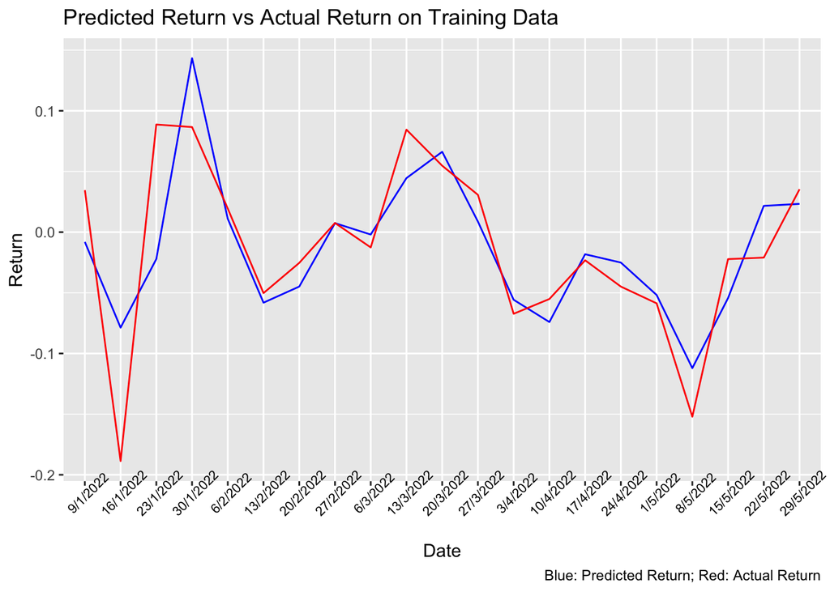

```r
graph_1 = data.frame(x1 = data_train$Date, y1 = predicted_return_train, y2 = data_train$close_return)


ggplot(graph_1, aes(x = x1)) + geom_line(aes(y = y1, group = 1), color = "blue") + geom_line(aes(y = y2, group = 1), color = "red") + xlab('Date') + ylab('Return') + labs(title="Predicted Return vs Actual Return on Training Data") + theme(axis.text.x = element_text(color = "black", size = 8, angle = 45)) + scale_x_discrete(limits = data_train$Date) + labs(caption = "Blue: Predicted Return; Red: Actual Return")
```

```r
# Predicted Return vs Actual Return on Test Data

signs = c()
signs_word = c()

for (i in 1:length(predicted_return))
  if (sign(predicted_return[i]) == sign(data_test$close_return[i])){
  signs[i] = 1
  signs_word[i] = "same"
  } else{
  signs[i] = 0
  signs_word[i] = "different"
  }


table_2 = data.frame(data_test$Date, predicted_return, data_test$close_return, signs_word)

table_2 %>%
  knitr::kable(caption = "Table 2: Predicted Return vs Actual Return on Test Data", align = "lrrr", digits = 3, col.name = c("Date", "Predicted Return", "Actual Return", "Sign")) %>%
  kableExtra::kable_styling(bootstrap_options = "striped", full_width = FALSE)
```

Table 2: Predicted Return vs Actual Return on Test Data

| Date | Predicted Return | Actual Return | Sign |
| --- | --- | --- | --- |
| 5/6/2022 | -0.025 | -0.049 | same |
| 12/6/2022 | -0.249 | -0.329 | same |
| 19/6/2022 | -0.018 | 0.131 | different |
| 26/6/2022 | 0.075 | -0.105 | different |
| 3/7/2022 | -0.001 | 0.122 | different |
| 10/7/2022 | 0.059 | -0.019 | different |
| 17/7/2022 | -0.009 | 0.060 | different |
| 24/7/2022 | 0.058 | 0.053 | same |
| 31/7/2022 | -0.045 | 0.019 | different |
| 7/8/2022 | 0.023 | 0.019 | same |
| 14/8/2022 | 0.009 | 0.052 | same |
| 21/8/2022 | 0.053 | 0.020 | same |

```r
accuray = sum(signs)/length(signs)

print(paste("The Accuray Rate of the Sign is", accuray))
```

```
## [1] "The Accuray Rate of the Sign is 0.5"
```

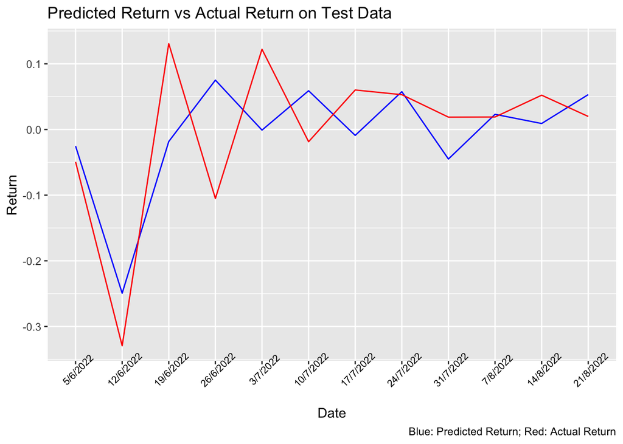

```r
graph_2 = data.frame(x1 = data_test$Date, y1 = predicted_return, y2 = data_test$close_return)

ggplot(graph_2, aes(x = x1)) + geom_line(aes(y = y1, group = 1), color = "blue") + geom_line(aes(y = y2, group = 1), color = "red") + xlab('Date') + ylab('Return') + labs(title="Predicted Return vs Actual Return on Test Data") + theme(axis.text.x = element_text(color = "black", size = 8, angle = 45)) + scale_x_discrete(limits = data_test$Date) + labs(caption = "Blue: Predicted Return; Red: Actual Return")
```

```r
average_close_return = c()

for (i in 1:length(predicted_return))
  average_close_return[i] = mean(data_train$close_return)


#Mean Absolute Error (MAE)
a = mae(data_test$close_return, predicted_return)
a_2 = mae(data_test$close_return, average_close_return)


#Mean Squared Error (MSE)
b = mse(data_test$close_return, predicted_return)
b_2 = mse(data_test$close_return, average_close_return)


# Root Mean Squared Error (RMSE)
c = rmse(data_test$close_return, predicted_return)
c_2 = rmse(data_test$close_return, average_close_return)



#Mean absolute percentage error (MAPE)
e = MAPE(data_test$close_return, predicted_return)
e_2 = MAPE(data_test$close_return, average_close_return)


#Relative absolute error (RAE)
f = rae(actual = data_test$close_return, predicted = predicted_return)
f_2 = rae(actual = data_test$close_return, predicted = average_close_return)

metric = c("Mean Absolute Error (MAE)", "Mean Squared Error (MSE)", "Root Mean Squared Error (RMSE)", "Mean absolute percentage error (MAPE)", "Relative absolute error (RAE)")
Model = c(a, b, c, e, f)
baseline_model = c(a_2, b_2, c_2, e_2, f_2)
high_low = c()
diff = c()

for (i in 1:length(Model))
  if (Model[i] > baseline_model[i]){
  high_low[i] = "Worse"
  diff[i] = Model[i] - baseline_model[i]
  } else{
  high_low[i] = "Better"
  diff[i] = Model[i] - baseline_model[i]
  }

table_3 = data.frame(metric, Model, baseline_model, high_low, diff)

table_3 %>%
  knitr::kable(caption = "Table 3: Regression Model vs Baseline Model", align = "lrrrr",  digits = 4, col.name = c("Metric","Regression Model", "Baseline Model", "Better or Worse", "Difference")) %>%
  kableExtra::kable_styling(bootstrap_options = "striped", full_width = FALSE)
```

Table 3: Regression Model vs Baseline Model

| Metric | Regression Model | Baseline Model | Better or Worse | Difference |
| --- | --- | --- | --- | --- |
| Mean Absolute Error (MAE) | 0.0710 | 0.0860 | Better | -0.0149 |
| Mean Squared Error (MSE) | 0.0079 | 0.0138 | Better | -0.0059 |
| Root Mean Squared Error (RMSE) | 0.0888 | 0.1176 | Better | -0.0288 |
| Mean absolute percentage error (MAPE) | 13.1332 | 6.4659 | Worse | 6.6673 |
| Relative absolute error (RAE) | 0.8632 | 1.0449 | Better | -0.1817 |

# 4 References

Hu, Z., Liu, W., Bian, J., Liu, X., & Liu, T.-Y. (2019, February 20). Listening to chaotic whispers: A deep learning framework for news-oriented stock trend prediction. arXiv.org. Retrieved November 21, 2022, from https://arxiv.org/abs/1712.02136

Kasper Welbers, Wouter Van Atteveldt & Kenneth Benoit (2017) Text Analysis in R, Communication Methods and Measures, 11:4, 245-265, DOI: 10.1080/19312458.2017.1387238

Person, J., P., & Stone. (2020, July 24). Thematic text analysis: New agendas for analyzing text content: 3 : T. Taylor & Francis. Retrieved November 21, 2022, from https://www.taylorfrancis.com/chapters/edit/10.4324/9781003064060-3/thematic-text-analysis-new-agendas-analyzing-text-content-philip-stone